```python
import pandas as pd, numpy as np

df = pd.read_csv('dataset_last_tp.csv', delimiter=';')
```

# EXAM

1. Exploratory Data Analsis (EDA): look closely at you data, the text, the target, any null values, any imbalance, non-numerical data to be converted?, etc.
2. Split into Training, Validation, & Test sets (0.75, 0.1, 0.15)
3. Clean Textual Data
4. Vectorize Texts (one hot encoder, tfidf, embeddings (word2vec with gensim, ELMO, BERT, GPT, etc.))
5. ML Classification model(s) or DL model or an ensemble of several ML/DL or both ML and DL models
6. Choose and justify the choice of the evaluation metric
7. Hyperparameter optimization (Cross validation - hyperopt - Gridsearch)
8. Evaluate on Test set
9. Use Lime to explain one text classification

**Comment all your steps: justify your choices, analyze the results (whether positive or negative), and finally conclude by suggesting improvements and making recommendations.**

You can use one notebook for all your work or seperate the EDA from the training and finally the testing and interpretability.  
You can also use .py scripts (classes/functions) and initialize/call them from the notebook.

The goal is to check that you understood how does an NLP data science project starts.  
you will be evaluated on the methods used and **the comments and analysis** you will provide.  
Bad test performance will not influence your grade as long as you propose improvements and elaborate on the reasons you think might have influenced this bad results.

**NB:** Imbalance can be fixed by Over/Under sampling and Data Augmentation.  
Using Textual Data Augmentation techniques (libraries like textattack.augmentation, NLPAug, backtranslations, etc.,) would be a bonus if used.

I have already started the EDA section for you.

# 1. Exploratory Data Analysis

```python
df
```

|  | medical notes | general_class | Unnamed: 2 | Unnamed: 3 | Unnamed: 4 | Unnamed: 5 | Unnamed: 6 | Unnamed: 7 | Unnamed: 8 | Unnamed: 9 | ... | Unnamed: 100 | Unnamed: 101 | Unnamed: 102 | Unnamed: 103 | Unnamed: 104 | Unnamed: 105 | Unnamed: 106 | Unnamed: 107 | Unnamed: 108 | Unnamed: 109 |
| --- | --- | --- | --- | --- | --- | --- | --- | --- | --- | --- | --- | --- | --- | --- | --- | --- | --- | --- | --- | --- | --- |
| 0 | SUBJECTIVE:, This 23-year-old white female pr... | Allergy / Immunology | NaN | NaN | NaN | NaN | NaN | NaN | NaN | NaN | ... | NaN | NaN | NaN | NaN | NaN | NaN | NaN | NaN | NaN | NaN |
| 1 | PAST MEDICAL HISTORY:, He has difficulty climb... | Bariatrics | NaN | NaN | NaN | NaN | NaN | NaN | NaN | NaN | ... | NaN | NaN | NaN | NaN | NaN | NaN | NaN | NaN | NaN | NaN |
| 2 | HISTORY OF PRESENT ILLNESS: , I have seen ABC ... | Bariatrics | NaN | NaN | NaN | NaN | NaN | NaN | NaN | NaN | ... | NaN | NaN | NaN | NaN | NaN | NaN | NaN | NaN | NaN | NaN |
| 3 | 2-D M-MODE: , ,1. Left atrial enlargement wit... | Cardiovascular / Pulmonary | NaN | NaN | NaN | NaN | NaN | NaN | NaN | NaN | ... | NaN | NaN | NaN | NaN | NaN | NaN | NaN | NaN | NaN | NaN |
| 4 | 1. The left ventricular cavity size and wall ... | Cardiovascular / Pulmonary | NaN | NaN | NaN | NaN | NaN | NaN | NaN | NaN | ... | NaN | NaN | NaN | NaN | NaN | NaN | NaN | NaN | NaN | NaN |
| ... | ... | ... | ... | ... | ... | ... | ... | ... | ... | ... | ... | ... | ... | ... | ... | ... | ... | ... | ... | ... | ... |
| 5022 | HISTORY:, I had the pleasure of meeting and e... | Allergy / Immunology | NaN | NaN | NaN | NaN | NaN | NaN | NaN | NaN | ... | NaN | NaN | NaN | NaN | NaN | NaN | NaN | NaN | NaN | NaN |
| 5023 | ADMITTING DIAGNOSIS: , Kawasaki disease.,DISCH... | Allergy / Immunology | NaN | NaN | NaN | NaN | NaN | NaN | NaN | NaN | ... | NaN | NaN | NaN | NaN | NaN | NaN | NaN | NaN | NaN | NaN |
| 5024 | SUBJECTIVE: , This is a 42-year-old white fema... | Allergy / Immunology | NaN | NaN | NaN | NaN | NaN | NaN | NaN | NaN | ... | NaN | NaN | NaN | NaN | NaN | NaN | NaN | NaN | NaN | NaN |
| 5025 | CHIEF COMPLAINT: , This 5-year-old male presen... | Allergy / Immunology | NaN | NaN | NaN | NaN | NaN | NaN | NaN | NaN | ... | NaN | NaN | NaN | NaN | NaN | NaN | NaN | NaN | NaN | NaN |
| 5026 | HISTORY: , A 34-year-old male presents today s... | Allergy / Immunology | NaN | NaN | NaN | NaN | NaN | NaN | NaN | NaN | ... | NaN | NaN | NaN | NaN | NaN | NaN | NaN | NaN | NaN | NaN |

5027 rows × 110 columns

```python
df.columns
```

```
Index(['medical notes', 'general_class', 'Unnamed: 2', 'Unnamed: 3',
       'Unnamed: 4', 'Unnamed: 5', 'Unnamed: 6', 'Unnamed: 7', 'Unnamed: 8',
       'Unnamed: 9',
       ...
       'Unnamed: 100', 'Unnamed: 101', 'Unnamed: 102', 'Unnamed: 103',
       'Unnamed: 104', 'Unnamed: 105', 'Unnamed: 106', 'Unnamed: 107',
       'Unnamed: 108', 'Unnamed: 109'],
      dtype='object', length=110)
```

```python
df = df[['medical notes', 'general_class',]]
```

```python
print("before Filtering:",len(df))
df = df[df.general_class.isin([' Surgery', ' Consult - History and Phy.',' Cardiovascular / Pulmonary', ' Orthopedic',
                               ' Radiology', ' General Medicine', ' Gastroenterology', ' Neurology',
                               ' SOAP / Chart / Progress Notes', ' Obstetrics / Gynecology',
                               ' Urology', ' Discharge Summary',
])]
print("after Filtering:",len(df))
```

```
before Filtering: 5027
after Filtering: 3861
```

[output not shown]

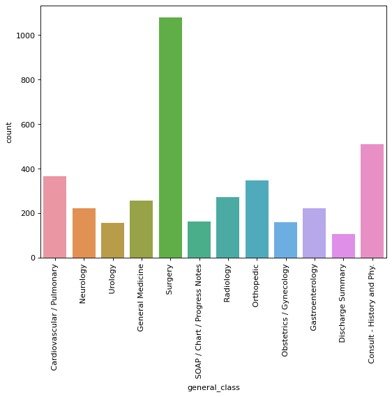

```python
import seaborn as sns, matplotlib.pyplot as plt
plt.figure(figsize=(8, 6), dpi=80)
sns.countplot(df.general_class)
plt.xticks(rotation=90)
```

```python
# checking duplicates and nan
len(df.drop_duplicates(subset=['medical notes'], keep='first')), len(df), len(df.dropna())
```

```
(2205, 3861, 3832)
```

```python
print("len df original:", len(df))
df.drop_duplicates(subset=['medical notes'], keep='first', inplace=True)
print('after removal of duplicates, len df:', len(df))
df.dropna(inplace=True)
print('after removal of nans, len df:', len(df))
df.reset_index(inplace=True)
```

```
len df original: 3861
after removal of duplicates, len df: 2205
after removal of nans, len df: 2204
```

```python
df = df.drop("index", axis=1)
```

### Classes distribution after the removal of duplicates and nans

The distribution changed for sevaral classes like:

- Cardiovascular / Pulmonary
- Neurology
- ...
- Gastroenterology
- Consult - History and Phy.

However, a clear imbalanced data is the case here.  
To deal with it, there are several approaches:

- undersampling
- oversampling

There are several Oversampling methods in NLP:

- simple duplication of data samples
- synonyms replacement
- backtranslation
- etc.

There are several libraries to do these techniques, however, we will first start by testing undersampling.

[output not shown]

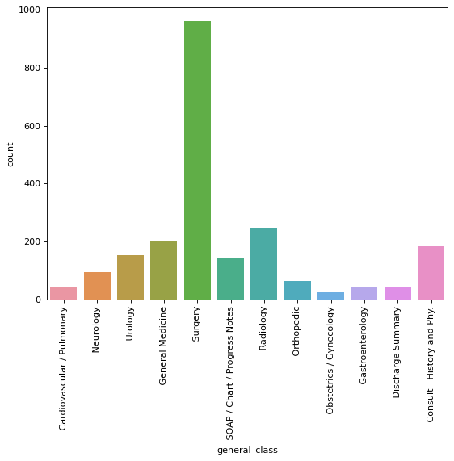

```python
import seaborn as sns, matplotlib.pyplot as plt
plt.figure(figsize=(8, 6), dpi=80)
sns.countplot(df.general_class)
plt.xticks(rotation=90)
```

```python
df.general_class.value_counts()
```

```
 Surgery                          961
 Radiology                        248
 General Medicine                 200
 Consult - History and Phy.       185
 Urology                          154
 SOAP / Chart / Progress Notes    144
 Neurology                         94
 Orthopedic                        64
 Cardiovascular / Pulmonary        44
 Discharge Summary                 43
 Gastroenterology                  41
 Obstetrics / Gynecology           26
Name: general_class, dtype: int64
```

```python
# cleaning text data

from bs4 import BeautifulSoup
import re

def strip(text):
    soup = BeautifulSoup(text, "html.parser")
    text = re.sub('\[[^]]*\]', '', soup.get_text())
    pattern=r"[^a-zA-Z\s]"#r"[^a-zA-Z0-9\s,']"
    text=re.sub(pattern,'',text)
    return text

df['medical notes']=df['medical notes'].apply(strip)
```

```python
# Example of a Text augmentation
# from textattack.augmentation import EmbeddingAugmenter
# augmenter = EmbeddingAugmenter()
# s = 'What I cannot create, I do not understand.'
# augmenter.augment(s)
# # ['What I notable create, I do not understand.', 'What I significant create, I do not understand.', 'What I cannot engender, I do not understand.', 'What I cannot creating, I do not understand.', 'What I cannot creations, I do not understand.', 'What I cannot create, I do not comprehend.', 'What I cannot create, I do not fathom.', 'What I cannot create, I do not understanding.', 'What I cannot create, I do not understands.', 'What I cannot create, I do not understood.', 'What I cannot create, I do not realise.']
```

# Undersampling

```python
#Undersampling

# determine the size of the smallest class
min_size = df.general_class.value_counts().min()

# determine the desired size of the balanced dataset
balanced_size = min_size * len(df.general_class.unique())

# create a new empty dataframe for the balanced dataset
df_undersample = pd.DataFrame(columns=df.columns)

# for each class, randomly select 26 instances to keep
for class_name in df.general_class.unique():
    df_class = df[df.general_class == class_name]
    df_class_sampled = df_class.sample(n=min_size, random_state=42)
    df_undersample = pd.concat([df_undersample, df_class_sampled])

# shuffle the balanced dataset
df_undersample = df_undersample.sample(frac=1, random_state=42)
```

```python
# Split into Training, Validation, & Test sets (0.75, 0.1, 0.15)

from sklearn.model_selection import train_test_split

# split the data into training and temporary sets (0.75 for training and 0.25 for temp)
df_train, df_temp, y_train, y_temp = train_test_split(df_undersample['medical notes'], df_undersample['general_class'], test_size=0.25, random_state=42)

# split the temp data into validation and test sets (0.4 for validation and 0.6 for test)
df_val, df_test, y_val, y_test = train_test_split(df_temp, y_temp, test_size=0.6, random_state=42)

# print the shapes of the resulting sets
print("Training set shape:", df_train.shape)
print("Validation set shape:", df_val.shape)
print("Test set shape:", df_test.shape)
```

```
Training set shape: (234,)
Validation set shape: (31,)
Test set shape: (47,)
```

```python
from sklearn.feature_extraction.text import TfidfVectorizer

# Initialize a TfidfVectorizer object
vectorizer = TfidfVectorizer()

# Fit the vectorizer to the training data and transform it
df_train = vectorizer.fit_transform(df_train)

# Transform the validation and test data using the same vectorizer
df_val = vectorizer.transform(df_val)
df_test = vectorizer.transform(df_test)
```

```python
from sklearn.linear_model import LogisticRegression

# Initialize a logistic regression model
model = LogisticRegression()

# Train the model on the training data
model.fit(df_train, y_train)

# Evaluate the model on the validation set
accuracy = model.score(df_val, y_val)
print("Validation accuracy:", accuracy)
```

```
Validation accuracy: 0.45161290322580644
```

```python
from sklearn.tree import DecisionTreeClassifier

model = DecisionTreeClassifier(random_state=42)

model.fit(df_train, y_train)

score = model.score(df_val, y_val)
print("Decision Tree Classifier accuracy:", score)
```

```
Decision Tree Classifier accuracy: 0.3225806451612903
```

```python
from sklearn.ensemble import RandomForestClassifier

model = RandomForestClassifier(random_state=42)

model.fit(df_train, y_train)

score = model.score(df_val, y_val)
print("Decision Tree Classifier accuracy:", score)
```

```
Decision Tree Classifier accuracy: 0.5806451612903226
```

### Justification

After undersampling our data, scores obtained from the Logistic Regression, Decision Tree Classifier and Random Forest Classifier models all performed badly. Random Forest Classifier performed the best out of the three models with an accuracy score of 0.58. This is most likely because undersampling resulted in the datase being too small to make good predictions.

To obtain a balanced sample through undersampling, the sample size of the smallest sample is taken (in this case, 26 from the "Obstetrics / Gynecology" class). This means that samples of all other classes were reduced to 26.

Models perform well when it is trained on large sets of data. With such a small sample, it comes as no surprise we were not able to build a good prediction model.

# Oversampling

```python
#Duplication Oversampling

# determine the size of the largest class
max_size = df.general_class.value_counts().max()

# determine the desired size of the balanced dataset
balanced_size = max_size * len(df.general_class.unique())

# create a new empty dataframe for the balanced dataset
df_duplication_oversample = pd.DataFrame(columns=df.columns)

# for each class, duplicate instances until there are max_size instances
for class_name in df.general_class.unique():
    df_class = df[df.general_class == class_name]
    n_duplicates = max_size - len(df_class)
    if n_duplicates > 0:
        df_duplicates = df_class.sample(n=n_duplicates, replace=True, random_state=42)
        df_class = pd.concat([df_class, df_duplicates])
    df_duplication_oversample = pd.concat([df_duplication_oversample, df_class])

# shuffle the balanced dataset
df_duplication_oversample = df_duplication_oversample.sample(frac=1, random_state=42)
```

```python
# Split into Training, Validation, & Test sets (0.75, 0.1, 0.15)

from sklearn.model_selection import train_test_split

# split the data into training and temporary sets (0.75 for training and 0.25 for temp)
df_train, df_temp, y_train, y_temp = train_test_split(df_duplication_oversample['medical notes'], df_duplication_oversample['general_class'], test_size=0.25, random_state=42)

# split the temp data into validation and test sets (0.4 for validation and 0.6 for test)
df_val, df_test, y_val, y_test = train_test_split(df_temp, y_temp, test_size=0.6, random_state=42)

# print the shapes of the resulting sets
print("Training set shape:", df_train.shape)
print("Validation set shape:", df_val.shape)
print("Test set shape:", df_test.shape)
```

```
Training set shape: (8649,)
Validation set shape: (1153,)
Test set shape: (1730,)
```

```python
from sklearn.feature_extraction.text import TfidfVectorizer

# Initialize a TfidfVectorizer object
vectorizer = TfidfVectorizer()

# Fit the vectorizer to the training data and transform it
df_train_vec = vectorizer.fit_transform(df_train)

# Transform the validation and test data using the same vectorizer
df_val_vec = vectorizer.transform(df_val)
df_test_vec = vectorizer.transform(df_test)
```

```python
from sklearn.linear_model import LogisticRegression

# Initialize a logistic regression model
model = LogisticRegression()

# Train the model on the training data
model.fit(df_train_vec, y_train)

# Evaluate the model on the validation set
accuracy = model.score(df_val_vec, y_val)
print("Validation accuracy:", accuracy)
```

```
Validation accuracy: 0.98959236773634
```

```python
from sklearn.tree import DecisionTreeClassifier

model = DecisionTreeClassifier(random_state=42)

model.fit(df_train_vec, y_train)

score = model.score(df_val_vec, y_val)
print("Decision Tree Classifier accuracy:", score)
```

```
Decision Tree Classifier accuracy: 0.9800520381613183
```

```python
from sklearn.ensemble import RandomForestClassifier

model = RandomForestClassifier(random_state=42)

model.fit(df_train_vec, y_train)

score = model.score(df_val_vec, y_val)
print("Decision Tree Classifier accuracy:", score)
```

```
Decision Tree Classifier accuracy: 0.997398091934085
```

Random Forest Classifier got the highest accuracy score. We will further evaluate with this model.

### Evaluation metric choice

Accuracy measures the fraction of correctly classified instances among the total instances. It is a good metric when the classes are balanced and the goal is to have an overall idea of the model's performance.

Since we have a dataset with balanced classes, accuracy score is a good option for evaluating the model's performance.

```python
# Hyperparameter optimization

from sklearn.model_selection import GridSearchCV
from sklearn.ensemble import RandomForestClassifier

# define the parameter space to search
param_grid = {
    'n_estimators': [50, 100, 150],
    'max_depth': [10, 20, 30],
    'min_samples_split': [2, 5, 10],
    'min_samples_leaf': [1, 2, 4],
}

# perform grid search with cross-validation
grid_search = GridSearchCV(estimator=model, param_grid=param_grid, cv=5, n_jobs=-1)
grid_search.fit(df_train_vec, y_train)

# print the best hyperparameters and their corresponding score
print("Best hyperparameters:", grid_search.best_params_)
print("Validation accuracy:", grid_search.best_score_)
```

```
Best hyperparameters: {'max_depth': 30, 'min_samples_leaf': 1, 'min_samples_split': 5, 'n_estimators': 150}
Validation accuracy: 0.9860100896973425
```

```python
# evaluating model on test set

test_score = model.score(df_test_vec, y_test)
print("Random Forest Classifier accuracy on test set:", test_score)
```

```
Random Forest Classifier accuracy on test set: 0.9965317919075144
```

## Lime Interpretation

```python
med_notes = df['medical notes']
```

```python
df_train_nlp = med_notes[df_train.index]
df_test_nlp = med_notes[df_test.index]
```

```python
from sklearn.pipeline import make_pipeline
from lime.lime_text import LimeTextExplainer

pipeline = make_pipeline(vectorizer, model)

lime_explainer = LimeTextExplainer(class_names=['Surgery', 'Radiology', 'General Medicine',
                                                'Consult - History and Phy.','Urology',
                                                'SOAP / Chart / Progress Notes', 'Neurology',
                                                'Orthopedic','Cardiovascular / Pulmonary',
                                                'Discharge Summary','Gastroenterology',
                                                'Obstetrics / Gynecology'])
```

```python
lime_explainer.explain_instance(df_test_nlp[df_test_nlp.index==5].values[0],
                                    pipeline.predict_proba, num_features=4).show_in_notebook(text=True)
```

[output not shown]

```python
lime_explainer.explain_instance(df_test_nlp[df_test_nlp.index==24].values[0],
                                    pipeline.predict_proba, num_features=4).show_in_notebook(text=True)
```

[output not shown]